# Optimizing Advertising Budget Allocation

Kendra Mosholder

# Introduction

This analysis addresses a common business challenge: how to allocate a fixed advertising budget across multiple channels to maximize sales.  
Using a dataset of advertising spend on TV, radio, and newspapers, I applied regression models and budget simulations to evaluate each channel’s effectiveness.

The goal was to identify the most profitable allocation strategy while highlighting channel interactions, potential diminishing returns, and the limits of the available data.

# Data

```r
csv_path <- "C:/Users/Kendra/OneDrive/Documents/Data analysis/advertising.csv"

ads <- read.csv(csv_path, stringsAsFactors = FALSE)
names(ads) <- tolower(names(ads))

stopifnot(all(c("tv","radio","newspaper","sales") %in% names(ads)))
dim(ads)
```

```
## [1] 200   4
```

```r
summary(ads[, c("tv","radio","newspaper","sales")])
```

```
##        tv             radio          newspaper          sales
##  Min.   :  0.70   Min.   : 0.000   Min.   :  0.30   Min.   : 1.60
##  1st Qu.: 74.38   1st Qu.: 9.975   1st Qu.: 12.75   1st Qu.:11.00
##  Median :149.75   Median :22.900   Median : 25.75   Median :16.00
##  Mean   :147.04   Mean   :23.264   Mean   : 30.55   Mean   :15.13
##  3rd Qu.:218.82   3rd Qu.:36.525   3rd Qu.: 45.10   3rd Qu.:19.05
##  Max.   :296.40   Max.   :49.600   Max.   :114.00   Max.   :27.00
```

## Insights

- 200 observations and 4 variables.
- TV spend up to ~296k, Radio up to ~50k, Newspaper up to ~114k, Sales up to ~27k.
- Data is clean and ready for analysis.

# Exploratory Data Analysis

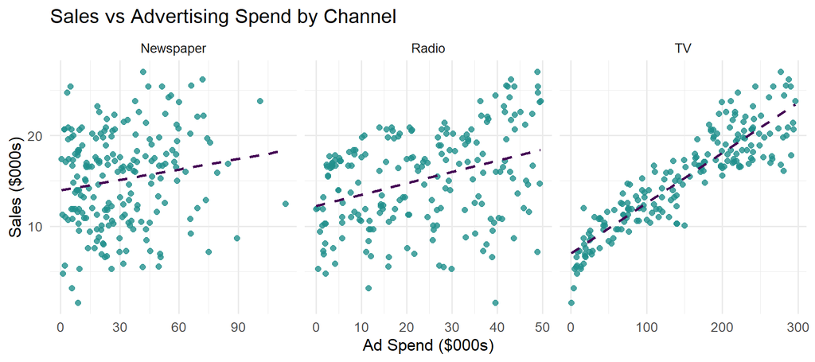

```r
ads_long <- ads %>%
  select(sales, tv, radio, newspaper) %>%
  rename(TV = tv, Radio = radio, Newspaper = newspaper) %>%
  pivot_longer(c(TV, Radio, Newspaper), names_to = "Channel", values_to = "Spend")

ggplot(ads_long, aes(x = Spend, y = sales)) +
  geom_point(alpha = 0.8, size = 2, color = viridis(3)[2]) +
  geom_smooth(method = "lm", se = FALSE, linetype = "dashed", color = viridis(3)[1]) +
  facet_wrap(~ Channel, nrow = 1, scales = "free_x") +
  labs(title = "Sales vs Advertising Spend by Channel",
       x = "Ad Spend ($000s)", y = "Sales ($000s)") +
  theme_minimal(base_size = 13)
```

## Insights

- TV has the strongest positive relationship with sales.
- Radio shows a moderate positive relationship.
- Newspaper shows little to no relationship with sales.

# Baseline Regression

```r
base_model <- lm(sales ~ tv + radio + newspaper, data = ads)
summary(base_model)
```

```
##
## Call:
## lm(formula = sales ~ tv + radio + newspaper, data = ads)
##
## Residuals:
##     Min      1Q  Median      3Q     Max
## -7.3034 -0.8244 -0.0008  0.8976  3.7473
##
## Coefficients:
##              Estimate Std. Error t value Pr(>|t|)
## (Intercept) 4.6251241  0.3075012  15.041   <2e-16 ***
## tv          0.0544458  0.0013752  39.592   <2e-16 ***
## radio       0.1070012  0.0084896  12.604   <2e-16 ***
## newspaper   0.0003357  0.0057881   0.058    0.954
## ---
## Signif. codes:  0 '***' 0.001 '**' 0.01 '*' 0.05 '.' 0.1 ' ' 1
##
## Residual standard error: 1.662 on 196 degrees of freedom
## Multiple R-squared:  0.9026, Adjusted R-squared:  0.9011
## F-statistic: 605.4 on 3 and 196 DF,  p-value: < 2.2e-16
```

## Insights

- TV and Radio are statistically significant predictors of sales.
- Newspaper is not significant.
- The model explains about 90% of the variation in sales (Adjusted R² ≈ 0.90).

# Interaction Model

```r
int_model <- lm(sales ~ tv * radio + newspaper, data = ads)
summary(int_model)
```

```
##
## Call:
## lm(formula = sales ~ tv * radio + newspaper, data = ads)
##
## Residuals:
##     Min      1Q  Median      3Q     Max
## -6.2685 -0.8765 -0.0480  0.9339  3.6521
##
## Coefficients:
##              Estimate Std. Error t value Pr(>|t|)
## (Intercept) 6.172e+00  4.192e-01  14.722  < 2e-16 ***
## tv          4.355e-02  2.498e-03  17.433  < 2e-16 ***
## radio       4.146e-02  1.513e-02   2.740  0.00671 **
## newspaper   1.349e-03  5.454e-03   0.247  0.80492
## tv:radio    4.439e-04  8.699e-05   5.103 7.91e-07 ***
## ---
## Signif. codes:  0 '***' 0.001 '**' 0.01 '*' 0.05 '.' 0.1 ' ' 1
##
## Residual standard error: 1.565 on 195 degrees of freedom
## Multiple R-squared:  0.9141, Adjusted R-squared:  0.9123
## F-statistic: 518.6 on 4 and 195 DF,  p-value: < 2.2e-16
```

## Insights

- The TV × Radio interaction is statistically significant.
- Combining channels produces stronger results than using them alone.
- Adjusted R² ≈ 0.91 (slight improvement over baseline).

# Curved Model (Diminishing Returns Test)

```r
curve_model <- lm(sales ~ tv + I(tv^2) + radio + I(radio^2) + tv:radio, data = ads)
summary(curve_model)
```

```
##
## Call:
## lm(formula = sales ~ tv + I(tv^2) + radio + I(radio^2) + tv:radio,
##     data = ads)
##
## Residuals:
##     Min      1Q  Median      3Q     Max
## -5.0642 -0.7938 -0.0079  0.7480  3.4044
##
## Coefficients:
##               Estimate Std. Error t value Pr(>|t|)
## (Intercept)  5.153e+00  4.499e-01  11.452  < 2e-16 ***
## tv           7.554e-02  4.882e-03  15.473  < 2e-16 ***
## I(tv^2)     -1.085e-04  1.506e-05  -7.205 1.25e-11 ***
## radio       -3.354e-02  2.712e-02  -1.237  0.21767
## I(radio^2)   1.770e-03  5.149e-04   3.437  0.00072 ***
## tv:radio     4.145e-04  7.594e-05   5.459 1.45e-07 ***
## ---
## Signif. codes:  0 '***' 0.001 '**' 0.01 '*' 0.05 '.' 0.1 ' ' 1
##
## Residual standard error: 1.363 on 194 degrees of freedom
## Multiple R-squared:  0.9351, Adjusted R-squared:  0.9335
## F-statistic: 559.3 on 5 and 194 DF,  p-value: < 2.2e-16
```

## Insights

- The negative TV² term suggests possible diminishing returns.
- The dataset lacks higher budget levels to confirm this pattern.
- Within the observed range, sales keep increasing with spend.
- Adjusted R² ≈ 0.93 (best fit so far).

# Budget Allocation Simulation

```r
total_budget <- 100
step_size <- 5
radio_cap <- floor(max(ads$radio))

alloc_grid <- expand.grid(
  tv = seq(0, total_budget, by = step_size),
  radio = seq(0, total_budget, by = step_size)
) %>%
  filter(tv + radio == total_budget, radio <= radio_cap)

alloc_grid$pred_sales <- predict(curve_model, newdata = alloc_grid)

best_alloc <- alloc_grid %>%
  arrange(desc(pred_sales)) %>%
  slice(1)

best_alloc
```

```
##   tv radio pred_sales
## 1 55    45   12.07971
```

## Insights

- Best allocation ≈ TV 55k / Radio 45k.
- Predicted sales ≈ 12.1k.
- A balanced mix outperforms single-channel spend.

# Visualizations

## Individual vs Combined Impact

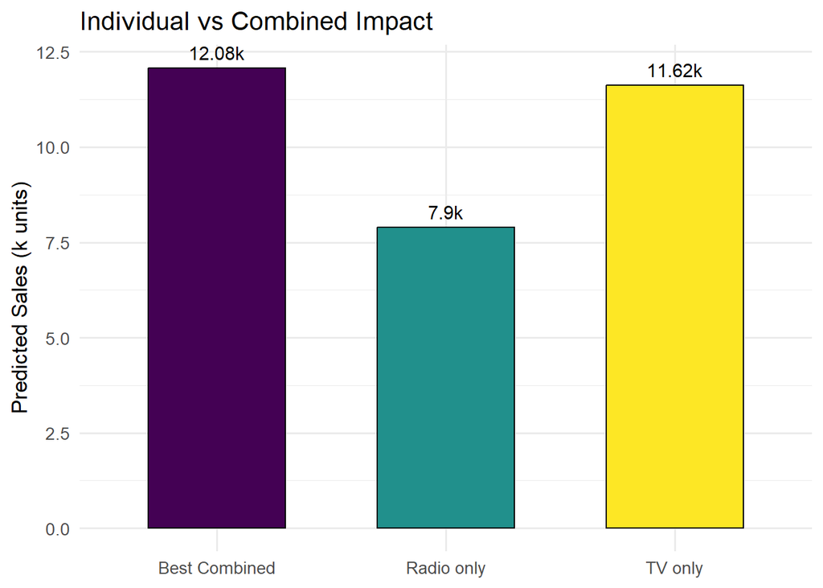

```r
scenarios <- tibble(
  scenario = c("TV only", "Radio only", "Best Combined"),
  tv = c(100, 0, best_alloc$tv),
  radio = c(0, 50, best_alloc$radio)
) %>%
  rowwise() %>%
  mutate(
    pred_sales = predict(curve_model, newdata = data.frame(tv = tv, radio = radio)),
    label = paste0(round(pred_sales, 2), "k")
  ) %>%
  ungroup()

ggplot(scenarios, aes(x = scenario, y = pred_sales, fill = scenario)) +
  geom_col(width = 0.6, color = "black") +
  geom_text(aes(label = label), vjust = -0.6, size = 4) +
  scale_fill_viridis(discrete = TRUE, option = "viridis") +
  labs(title = "Individual vs Combined Impact",
       y = "Predicted Sales (k units)", x = NULL) +
  theme_minimal(base_size = 13) +
  theme(legend.position = "none")
```

## Insights

- TV only ≈ 11.6k sales.
- Radio only (capped at 50k) ≈ 7.9k.
- Best combined ≈ 12.1k sales.

# Heatmap of $100k Allocation (Self‑Contained)

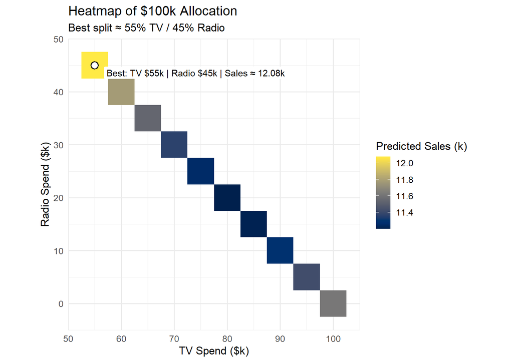

```r
# Rebuild grid locally so this chunk never depends on previous chunks
total_budget <- 100
step_size <- 5
radio_cap <- floor(max(ads$radio))

alloc_grid_hm <- expand.grid(
  tv = seq(0, total_budget, by = step_size),
  radio = seq(0, total_budget, by = step_size)
) %>%
  dplyr::filter(tv + radio == total_budget, radio <= radio_cap)

# Guard against empty grid
stopifnot(nrow(alloc_grid_hm) > 0)

alloc_grid_hm$pred_sales <- predict(curve_model, newdata = alloc_grid_hm)

best_alloc_hm <- alloc_grid_hm %>%
  dplyr::arrange(dplyr::desc(pred_sales)) %>%
  dplyr::slice(1)

ggplot(alloc_grid_hm, aes(tv, radio, fill = pred_sales)) +
  geom_tile() +
  geom_contour(aes(z = pred_sales), color = "white", linewidth = 0.4, bins = 8) +
  geom_point(data = best_alloc_hm, aes(tv, radio),
             shape = 21, size = 3.5, stroke = 1, color = "black", fill = "white") +
  geom_label(data = best_alloc_hm,
             aes(tv, radio, label = paste0("Best: TV $", tv, "k | Radio $", radio, "k | Sales ≈ ", round(pred_sales,2), "k")),
             hjust = -0.05, vjust = 1.1, label.size = 0, fill = "white", color = "black") +
  scale_fill_viridis(option = "cividis", name = "Predicted Sales (k)") +
  labs(title = "Heatmap of $100k Allocation",
       subtitle = "Best split ≈ 55% TV / 45% Radio",
       x = "TV Spend ($k)", y = "Radio Spend ($k)") +
  coord_fixed() +
  theme_minimal(base_size = 13)
```

## Insights

- Heatmap confirms best allocation ≈ 55/45 split.
- Newspaper excluded (not predictive).

# Budget Sensitivity (Observed Range)

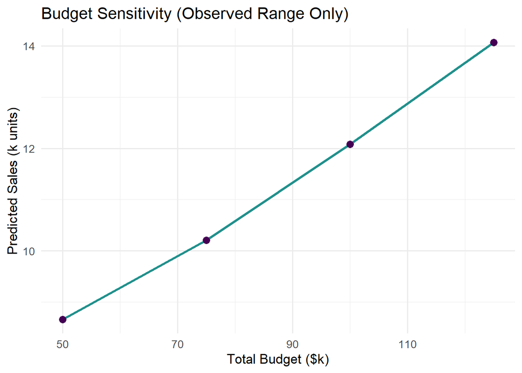

```r
budgets <- seq(50, 125, by = 25)

opt_sales <- sapply(budgets, function(b){
  grid <- expand.grid(
    tv = seq(0, b, by = 5),
    radio = seq(0, b, by = 5)
  ) %>%
    filter(tv + radio == b, radio <= radio_cap)
  max(predict(curve_model, newdata = grid))
})

sensitivity_df <- tibble(budget = budgets, sales = opt_sales)

ggplot(sensitivity_df, aes(budget, sales)) +
  geom_line(linewidth = 1.2, color = viridis(3)[2]) +
  geom_point(size = 3, color = viridis(3)[1]) +
  labs(title = "Budget Sensitivity (Observed Range Only)",
       x = "Total Budget ($k)", y = "Predicted Sales (k units)") +
  theme_minimal(base_size = 13)
```

## Insights

- From $50k to $125k, predicted sales rise steadily.
- No saturation point is visible in this dataset.
- More data is needed at higher budgets to test for diminishing returns.

# Recommendations

- Allocate ~$100k across TV and Radio with an optimal split near **55% TV / 45% Radio**.
- Do not allocate to Newspaper (no measurable effect in this dataset).
- If budgets increase beyond $100k, collect additional data to test for diminishing returns.
- Incorporate digital channels in future analyses for completeness.

# Key Insights

- I framed a business question (how to spend a fixed ad budget) as a data problem.
- I used regression and simulation to compare scenarios and find an optimal mix.
- Multichannel (TV + Radio) outperforms single-channel within the observed range.
- I recognized dataset limits and proposed next steps.